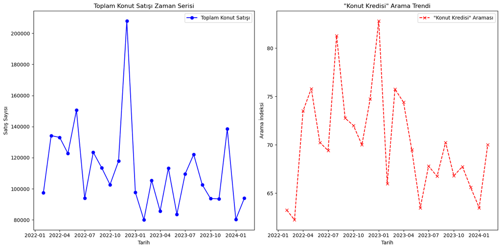

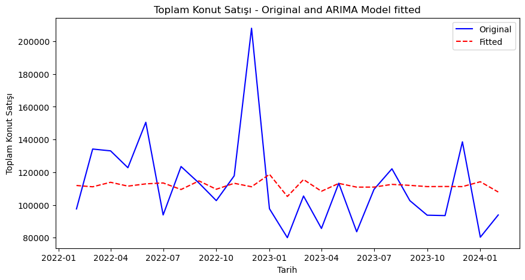

```
                               SARIMAX Results
==============================================================================
Dep. Variable:     Toplam_Konut_Satis   No. Observations:                   25
Model:                 ARIMA(1, 0, 1)   Log Likelihood                -290.484
Date:                Fri, 05 Apr 2024   AIC                            588.969
Time:                        23:05:04   BIC                            593.844
Sample:                    02-01-2022   HQIC                           590.321
                         - 02-01-2024
Covariance Type:                  opg
==============================================================================
                 coef    std err          z      P>|z|      [0.025      0.975]
------------------------------------------------------------------------------
const       1.119e+05   7748.182     14.442      0.000    9.67e+04    1.27e+05
ar.L1         -0.7846      1.571     -0.499      0.617      -3.863       2.294
ma.L1          0.8492      1.395      0.609      0.543      -1.885       3.583
sigma2      7.995e+08      0.224   3.58e+09      0.000    7.99e+08    7.99e+08
===================================================================================
Ljung-Box (L1) (Q):                   0.17   Jarque-Bera (JB):                32.74
Prob(Q):                              0.68   Prob(JB):                         0.00
Heteroskedasticity (H):               0.90   Skew:                             1.82
Prob(H) (two-sided):                  0.89   Kurtosis:                         7.26
===================================================================================

Warnings:
[1] Covariance matrix calculated using the outer product of gradients (complex-step).
[2] Covariance matrix is singular or near-singular, with condition number 1.75e+25. Standard errors may be unstable.
```

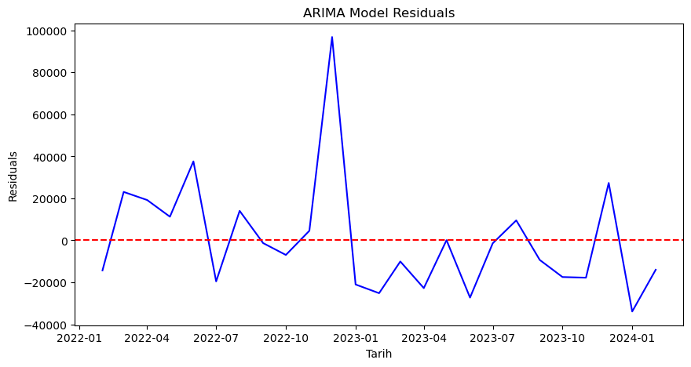

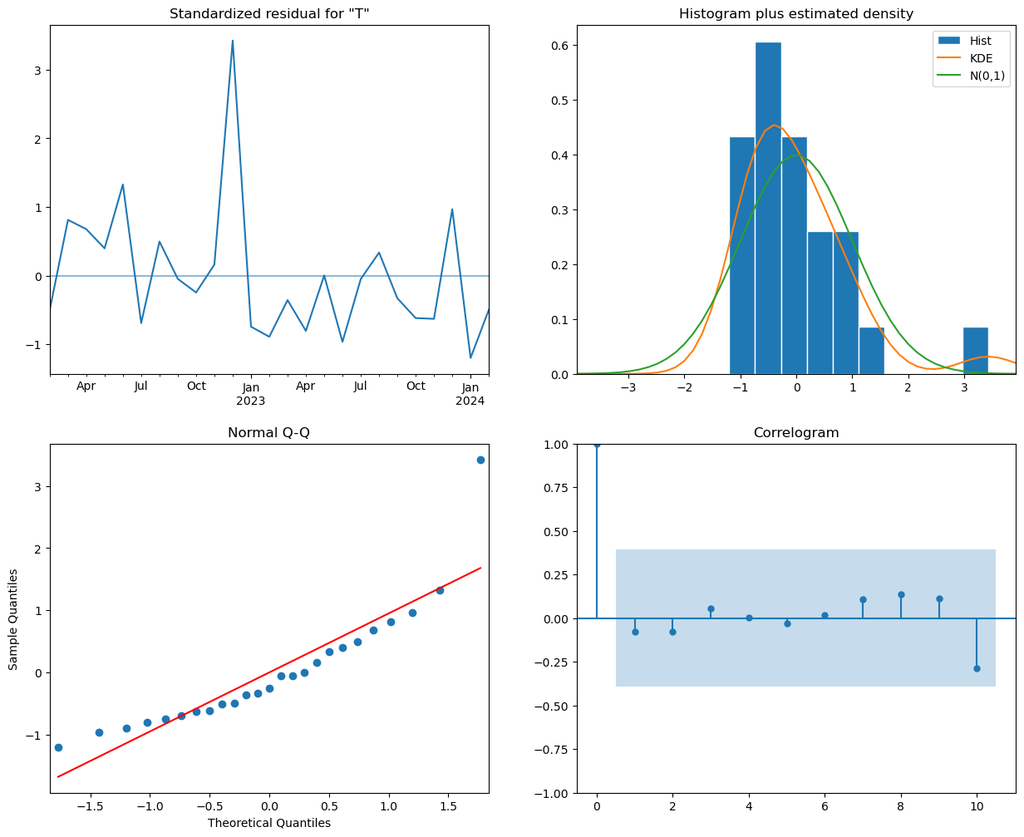

```python
import pandas as pd
import numpy as np
import matplotlib.pyplot as plt
from statsmodels.tsa.arima.model import ARIMA
from sklearn.metrics import mean_squared_error, r2_score

df_data = pd.DataFrame({
    'Ay': pd.date_range(start='2022-02-01', periods=25, freq='MS'),
    'Toplam_Konut_Satis': [
        97587, 134170, 133058, 122768, 150509, 93902, 123491, 113402,
        102660, 117806, 207963, 97708, 80031, 105476, 85652, 113276,
        83636, 109548, 122091, 102656, 93761, 93514, 138577, 80308, 93902
    ],
    'Konut_Kredisi_Aramasi': [
        63.25, 62.25, 73.5, 75.8, 70.25, 69.4, 81.25, 72.75,
        72, 70, 74.75, 82.8, 66, 75.75, 74.4, 69.5, 63.5, 67.8,
        66.75, 70.25, 66.8, 67.75, 65.6, 63.5, 70
    ]
})

df_data.set_index('Ay', inplace=True)

plt.figure(figsize=(14, 7))
plt.subplot(1, 2, 1)
plt.plot(df_data['Toplam_Konut_Satis'], marker='o', color='blue', label='Toplam Konut Satışı')
plt.title('Toplam Konut Satışı Zaman Serisi')
plt.xlabel('Tarih')
plt.ylabel('Satış Sayısı')
plt.legend()
plt.subplot(1, 2, 2)
plt.plot(df_data['Konut_Kredisi_Aramasi'], marker='x', linestyle='--', color='red', label='"Konut Kredisi" Araması')
plt.title('"Konut Kredisi" Arama Trendi')
plt.xlabel('Tarih')
plt.ylabel('Arama İndeksi')
plt.legend()
plt.tight_layout()
plt.show()

arima_model = ARIMA(df_data['Toplam_Konut_Satis'], order=(1, 0, 1))
arima_results = arima_model.fit()

fitted_values = arima_results.fittedvalues
plt.figure(figsize=(10, 5))
plt.plot(df_data.index, df_data['Toplam_Konut_Satis'], label='Original', color='blue')
plt.plot(df_data.index, fitted_values, label='Fitted', color='red', linestyle='--')
plt.title('Toplam Konut Satışı - Original and ARIMA Model fitted')
plt.xlabel('Tarih')
plt.ylabel('Toplam Konut Satışı')
plt.legend()
plt.show()

print(arima_results.summary())
residuals = arima_results.resid
plt.figure(figsize=(10, 5))
plt.plot(residuals, color='blue')
plt.axhline(0, linestyle='--', color='red')
plt.title('ARIMA Model Residuals')
plt.xlabel('Tarih')
plt.ylabel('Residuals')
plt.show()

arima_results.plot_diagnostics(figsize=(15, 12))
plt.show()
```

Introduction:

We're exploring the link between housing sales and searches for home loans. By analyzing these two data sets, we aim to see if people look up mortgages more often when more homes are sold. This can give insights into housing market trends.

Total Housing Sales Time Series Analysis

The first graph shows the "Total Housing Sales" over time. We observe significant fluctuations with some peaks, which may suggest seasonal patterns or responses to market changes. There is one particularly high peak in the series, which could indicate an outlier or an extraordinary event impacting housing sales at that time.

"Konut Kredisi" Search Trend Time Series Analysis

The second image represents the search trend for "Konut Kredisi," which means "housing loan" in Turkish. This trend also fluctuates over time, but without as pronounced peaks as the total sales data, which may imply a steadier interest in housing loans relative to the sales numbers.

Fitted vs. Original Values from the ARIMA Model

ARIMA Model Summary Output Analysis

The ARIMA model summary output indicates that the model has a constant term and coefficients for AR(1) and MA(1). The significance of these coefficients can tell us about the model's ability to explain the data.

Specifically:

The constant coefficient suggests a baseline level of sales over time. The AR(1) coefficient is negative, which is interesting and may suggest a corrective behavior in sales – a high sales month may be followed by a lower sales month. The MA(1) coefficient is positive but needs to be interpreted with caution as the standard error and z-value need to be considered for its significance.

Residual Analysis

The residual plot for the ARIMA model is critical for understanding model performance. Residuals should ideally be randomly distributed with no clear pattern. In this case, we observe some structure in the residuals, which suggests that the model is not capturing all the information in the data, and there could be room for improvement.

Diagnostic Plots Analysis

The diagnostic plots provide further insight into the model's residuals:

The standardized residual plot does not show any clear pattern, which is good. The histogram plus estimated density plot compares the distribution of residuals to a normal distribution. Here we see the residuals have some departure from normality, with some skewness visible. The Normal Q-Q plot compares the distribution of the residuals with a theoretical normal distribution. Points lying along the line suggest normality. There are some deviations, especially at the ends. The Correlogram (ACF plot) suggests that there is no significant autocorrelation in the residuals at various lags, which is a positive indicator for the model.

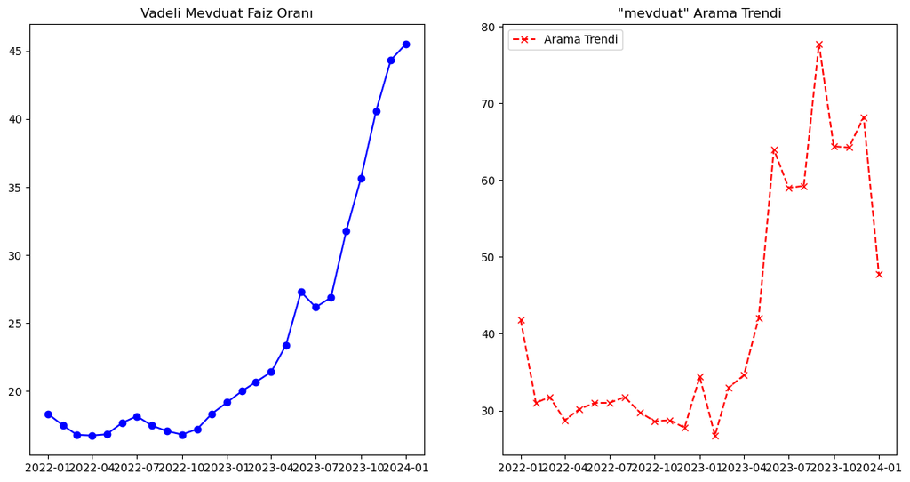

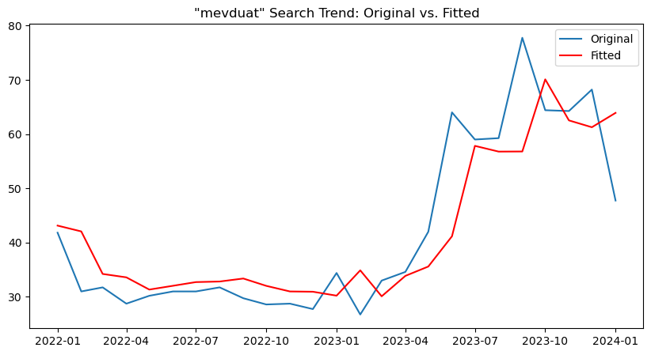

```
                               SARIMAX Results
==============================================================================
Dep. Variable:      "mevduat" Araması   No. Observations:                   25
Model:                 ARIMA(1, 0, 1)   Log Likelihood                 -88.376
Date:                Fri, 05 Apr 2024   AIC                            184.752
Time:                        23:05:57   BIC                            189.627
Sample:                    01-01-2022   HQIC                           186.104
                         - 01-01-2024
Covariance Type:                  opg
==============================================================================
                 coef    std err          z      P>|z|      [0.025      0.975]
------------------------------------------------------------------------------
const         43.1345     16.804      2.567      0.010      10.200      76.069
ar.L1          0.8710      0.121      7.171      0.000       0.633       1.109
ma.L1         -0.1524      0.441     -0.345      0.730      -1.017       0.712
sigma2        65.7450     16.409      4.007      0.000      33.583      97.907
===================================================================================
Ljung-Box (L1) (Q):                   0.00   Jarque-Bera (JB):                 9.49
Prob(Q):                              0.95   Prob(JB):                         0.01
Heteroskedasticity (H):               8.35   Skew:                             1.09
Prob(H) (two-sided):                  0.01   Kurtosis:                         5.09
===================================================================================

Warnings:
[1] Covariance matrix calculated using the outer product of gradients (complex-step).
```

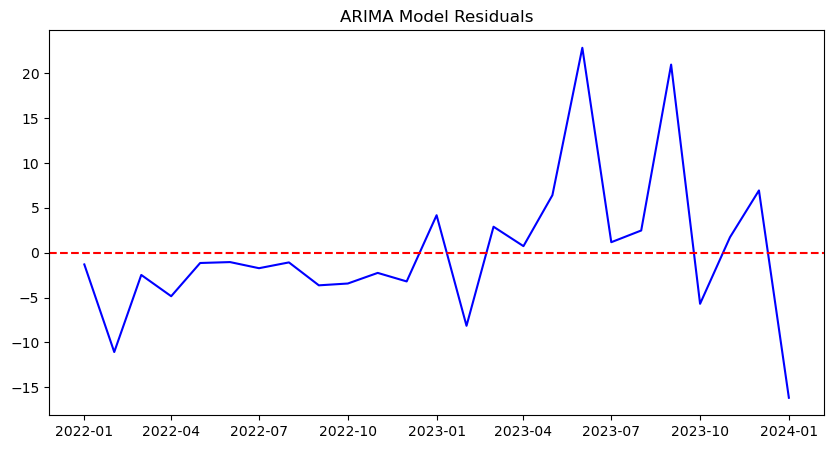

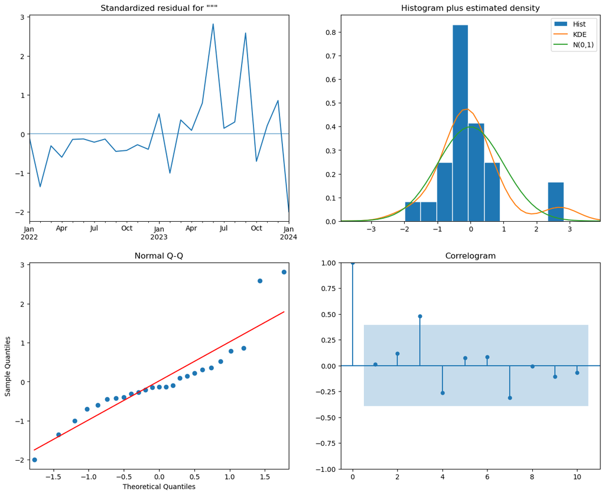

```python
import pandas as pd
import numpy as np
import matplotlib.pyplot as plt
from statsmodels.tsa.arima.model import ARIMA
from sklearn.metrics import mean_squared_error, r2_score

df_interest_data = pd.DataFrame({
    'Tarih': pd.date_range(start='2022-01-01', periods=25, freq='MS'),
    'Vadeli Mevduat Faiz Orani Ortalaması': [
        18.33, 17.48, 16.79, 16.74, 16.83, 17.66, 18.16, 17.47, 17.06,
        16.81, 17.20, 18.33, 19.17, 20.01, 20.67, 21.40, 23.35, 27.29,
        26.16, 26.88, 31.75, 35.64, 40.59, 44.34, 45.53
    ],
    '"mevduat" Araması': [
        41.83, 31, 31.75, 28.75, 30.2, 31, 31, 31.75, 29.75,
        28.6, 28.75, 27.75, 34.4, 26.75, 33, 34.6, 42, 64, 59, 59.25,
        77.75, 64.4, 64.25, 68.2, 47.75
    ]
})

df_interest_data['Tarih'] = pd.to_datetime(df_interest_data['Tarih'], format='%m-%Y')
df_interest_data.set_index('Tarih', inplace=True)

plt.figure(figsize=(14, 7))
plt.subplot(1, 2, 1)
plt.plot(df_interest_data['Vadeli Mevduat Faiz Orani Ortalaması'], marker='o', color='blue', label='Faiz Oranı')
plt.title('Vadeli Mevduat Faiz Oranı')
plt.subplot(1, 2, 2)
plt.plot(df_interest_data['"mevduat" Araması'], marker='x', linestyle='--', color='red', label='Arama Trendi')
plt.title('"mevduat" Arama Trendi')
plt.legend()
plt.show()

arima_model_interest = ARIMA(df_interest_data['"mevduat" Araması'], order=(1, 0, 1))
arima_results_interest = arima_model_interest.fit()

fitted_values_interest = arima_results_interest.fittedvalues
plt.figure(figsize=(10, 5))
plt.plot(df_interest_data.index, df_interest_data['"mevduat" Araması'], label='Original')
plt.plot(df_interest_data.index, fitted_values_interest, color='red', label='Fitted')
plt.title('"mevduat" Search Trend: Original vs. Fitted')
plt.legend()
plt.show()

print(arima_results_interest.summary())
residuals_interest = arima_results_interest.resid
plt.figure(figsize=(10, 5))
plt.plot(residuals_interest, color='blue')
plt.axhline(0, linestyle='--', color='red')
plt.title('ARIMA Model Residuals')
plt.show()

arima_results_interest.plot_diagnostics(figsize=(15, 12))
plt.show()
```

Introduction:

This study investigates whether higher term deposit interest rates spark an increase in online searches for term deposits, suggesting a correlation between rate changes and public interest in saving options.

Vadeli Mevduat Faiz Oranı (Term Deposit Interest Rate) Graph:

This line graph shows a significant upward trend, particularly towards the later dates, which suggests an increasing interest rate over time. This might reflect changing economic conditions or policy decisions affecting interest rates.

Original vs. Fitted Values Graph:

The graph shows the original "mevduat" search interest alongside the fitted values from the ARIMA model. The model seems to capture the overall trend of the data well, though there are periods where the fitted values diverge from the actual data, indicating potential areas where the model could be improved.

"mevduat" Arama Trendi (Deposit Search Trend) Graph:

There's a clear upward trend in the search interest for "mevduat," with some fluctuations. This could correlate with the increasing trend in interest rates, suggesting that higher rates may drive more online searches for deposit information.

ARIMA Model Summary:

Residuals Plot:

The residuals should ideally be centered around zero and exhibit no clear pattern. The provided plot shows some deviations from zero, which might suggest that the model is not fully capturing the underlying process or there are outliers affecting the residuals.

Standardized Residual Plot:

The plot should ideally show no clear trends or patterns. In the provided plot, there are some spikes, indicating moments where the model predictions deviate from the actual data.

Histogram Plus Estimated Density Plot:

The histogram of the residuals should resemble a normal distribution if the model fits the data well. The provided plot shows some skewness, indicating the distribution of residuals is not perfectly normal.

Normal Q-Q Plot:

This plot compares the quantiles of the residuals with the quantiles of a normal distribution. Points following the red line indicate normality. The provided plot shows some points deviating from the line, especially in the tails.

Correlogram (ACF Plot):

This plot shows the autocorrelations of the residuals at different lags. Ideally, these should not be significantly different from zero. The provided plot indicates some autocorrelation at specific lags, which could be a sign that the model could be further improved by including additional lags.

Concluding Remarks

The ARIMA model for the "mevduat" search interest indicates a strong autoregressive component and a significant upward trend in the search interest over time. However, the presence of autocorrelation in the residuals and deviations in the standardized residual plot suggests that the model may not be fully capturing the dynamic nature of the data. Further improvements to the model might include exploring different orders for the ARIMA components, incorporating seasonal terms, or including external variables that could explain the fluctuations in search interest.

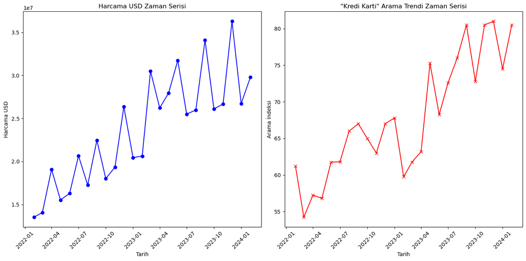

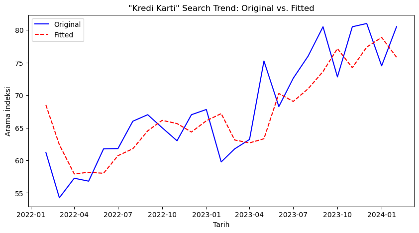

```
                                 SARIMAX Results
=================================================================================
Dep. Variable:     "Kredi Karti" Aramasi   No. Observations:                   25
Model:                    ARIMA(1, 0, 1)   Log Likelihood                 -74.485
Date:                   Fri, 05 Apr 2024   AIC                            156.971
Time:                           23:06:15   BIC                            161.846
Sample:                                0   HQIC                           158.323
                                    - 25
Covariance Type:                     opg
==============================================================================
                 coef    std err          z      P>|z|      [0.025      0.975]
------------------------------------------------------------------------------
const         68.4893      7.737      8.852      0.000      53.324      83.654
ar.L1          0.9412      0.101      9.277      0.000       0.742       1.140
ma.L1         -0.3848      0.322     -1.196      0.232      -1.015       0.246
sigma2        21.4068      6.325      3.384      0.001       9.010      33.804
===================================================================================
Ljung-Box (L1) (Q):                   0.04   Jarque-Bera (JB):                 0.08
Prob(Q):                              0.85   Prob(JB):                         0.96
Heteroskedasticity (H):               1.71   Skew:                             0.12
Prob(H) (two-sided):                  0.46   Kurtosis:                         2.85
===================================================================================

Warnings:
[1] Covariance matrix calculated using the outer product of gradients (complex-step).
```

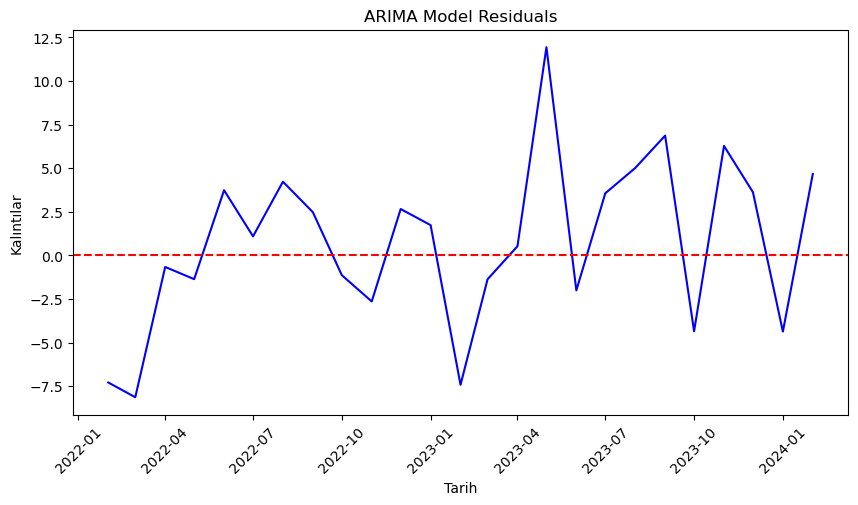

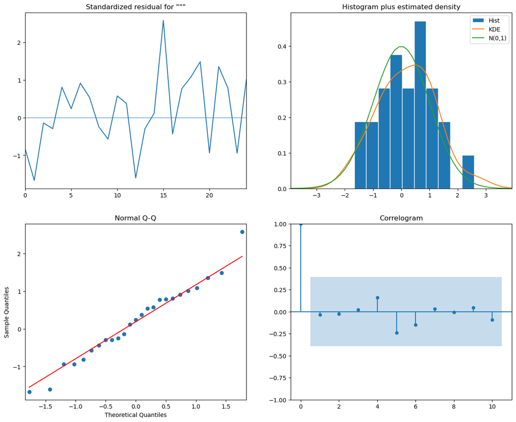

```python
import pandas as pd
import numpy as np
import matplotlib.pyplot as plt
from statsmodels.tsa.arima.model import ARIMA
from sklearn.metrics import mean_squared_error, r2_score

dates = pd.date_range(start='2022-02-01', periods=25, freq='MS')
spending_usd = [
    13534538, 14055458, 19083703, 15522304, 16286561,
    20652388, 17250116, 22456526, 18001589, 19330791,
    26357780, 20439482, 20625788, 30487662, 26218080,
    27937674, 31743949, 25502239, 25972424, 34108468,
    26096815, 26679197, 36287512, 26723161, 29776841
]
credit_card_searches = [
    61.2, 54.25, 57.25, 56.8, 61.75, 61.8, 66, 67, 65,
    63, 67, 67.8, 59.75, 61.75, 63.2, 75.25, 68.25,
    72.6, 76, 80.5, 72.8, 80.5, 81, 74.5, 80.5
]

df_credit_card_data = pd.DataFrame({
    'Tarih': dates,
    'Harcama USD': spending_usd,
    '"Kredi Karti" Aramasi': credit_card_searches
})

plt.figure(figsize=(14, 7))
plt.subplot(1, 2, 1)
plt.plot(df_credit_card_data['Tarih'], df_credit_card_data['Harcama USD'], marker='o', color='blue')
plt.title('Harcama USD Zaman Serisi')
plt.xlabel('Tarih')
plt.ylabel('Harcama USD')
plt.xticks(rotation=45)

plt.subplot(1, 2, 2)
plt.plot(df_credit_card_data['Tarih'], df_credit_card_data['"Kredi Karti" Aramasi'], marker='x', color='red')
plt.title('"Kredi Karti" Arama Trendi Zaman Serisi')
plt.xlabel('Tarih')
plt.ylabel('Arama İndeksi')
plt.xticks(rotation=45)
plt.tight_layout()
plt.show()

arima_model_cc = ARIMA(df_credit_card_data['"Kredi Karti" Aramasi'], order=(1, 0, 1))
arima_results_cc = arima_model_cc.fit()

fitted_values_cc = arima_results_cc.fittedvalues
plt.figure(figsize=(10, 5))
plt.plot(df_credit_card_data['Tarih'], df_credit_card_data['"Kredi Karti" Aramasi'], label='Original', color='blue')
plt.plot(df_credit_card_data['Tarih'], fitted_values_cc, label='Fitted', color='red', linestyle='--')
plt.title('"Kredi Karti" Search Trend: Original vs. Fitted')
plt.xlabel('Tarih')
plt.ylabel('Arama İndeksi')
plt.legend()
plt.show()

print(arima_results_cc.summary())
residuals_cc = arima_results_cc.resid
plt.figure(figsize=(10, 5))
plt.plot(df_credit_card_data['Tarih'], residuals_cc, color='blue')
plt.axhline(0, linestyle='--', color='red')
plt.title('ARIMA Model Residuals')
plt.xlabel('Tarih')
plt.ylabel('Kalıntılar')
plt.xticks(rotation=45)
plt.show()

arima_results_cc.plot_diagnostics(figsize=(15, 12))
plt.show()
```

Introduction:

We're looking at credit card spending and credit card search trends together to see if people search more when they spend more. This helps us understand if searches can tell us about spending habits.

Expenditure Time Series:

The plot shows significant fluctuations in spending over time with several noticeable peaks and troughs. This could indicate cyclical patterns, potentially related to seasonal buying behaviors or economic cycles.

"Kredi Kartı" Search Trend Time Series:

The search interest shows an overall increasing trend with some volatility. Notable spikes in search interest could correspond with marketing campaigns, changes in credit card rates, or seasonal factors that drive consumer interest in credit products.

ARIMA Model Fit to "Kredi Kartı" Search Interest:

The "Original vs. Fitted" plot compares the actual search interest values with those predicted by the ARIMA model. The model seems to follow the actual trend closely, capturing the general pattern in search interest. However, there are periods where the fitted values deviate from the actual ones, suggesting the model may not fully account for all variability in the data.

ARIMA Model Summary:

The constant term is significant, indicating a baseline level of search interest that is not explained by the model's AR and MA components. The AR(1) coefficient is positive and significant, suggesting that there is a strong positive autocorrelation in the series. A higher search interest in one period tends to be followed by a higher search interest in the next period. The MA(1) coefficient is negative, but not statistically significant, implying that the moving average component of the model does not provide additional explanatory power over the autoregressive component. The sigma^2 value is relatively small, which generally suggests that the model's predictions are close to the actual values.

Diagnostic Plots for the ARIMA Model:

The standardized residual plot does not show any obvious patterns or systematic structure, which is a positive sign that the model is capturing the data's variability well. The histogram and Q-Q plot indicate that the residuals are approximately normally distributed, with the Q-Q plot showing that most of the data points lie along the theoretical line. The correlogram shows that the autocorrelations of the residuals are within the confidence bounds for most lags, which suggests that the model residuals do not exhibit significant autocorrelation and, by extension, that the model is adequately capturing the time series' autocorrelation structure.

Conclusion:

The ARIMA model appears to provide a good fit for the "Kredi Kartı" search interest time series data, capturing the underlying trend and the autocorrelation in the observed data. However, as with any model, there may be room for improvement. For example, incorporating additional exogenous variables that might impact search interest, such as advertising spend or changes in credit card policies, could potentially enhance the model's predictive power. Moreover, testing different model orders or including seasonal terms might further improve the fit, especially if there are seasonal patterns in the data not captured by the current model specification.